# Tratamiento y depuración de datos

Julio, 2015

## Introducción

El *tratamiento* y *depuración* de **datos** es el procedimiento por el cual se identifican datos incompletos, incorrectos, inexactos, no pertinentes, etc. para posteriormente substituir, modificar o eliminar datos con el propósito de mejorar la calidad de la información.

[figure not shown]

Se estima que la extracción, limpieza, transformación y carga de datos representan aproximadamente el 70% del costo de un proyecto analítico.

## Manipulación de caractéres

Es muy probable que en su vida profesional se encuentre con algún conjunto de datos que contiene información sobre: nombres, números de teléfono, fechas, cantidades monetarias, coordenadas, etc.

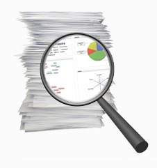

Además, que se desee:

- Eliminar un caracter especial
- Reemplazar algún caracter determinado
- Convertir las etiquetas en mayúsculas (o minúsculas)

Gran cantidad de personas modifican sus archivos de texto en Excel realizando miles de `Ctrl+C` & `Ctrl+V`.

## Abreviación de cadenas

Para iniciarnos en el tema consideraremos una base `USArrests` de ratios de violencia (asaltos, asesinatos, etc.) dentro de EEUU:

```r
head(USArrests)
```

```
#>            Murder Assault UrbanPop Rape
#> Alabama      13.2     236       58 21.2
#> Alaska       10.0     263       48 44.5
#> Arizona       8.1     294       80 31.0
#> Arkansas      8.8     190       50 19.5
#> California    9.0     276       91 40.6
#> Colorado      7.9     204       78 38.7
```

Almacenemos los nombres de los **Estados** en la variable `states.

```r
states <- rownames(USArrests)
head(states)
```

```
#> [1] "Alabama"    "Alaska"     "Arizona"    "Arkansas"   "California"
#> [6] "Colorado"
```

## Abreviación de cadenas

Supongamos que queremos abreviar los nombres de los **Estados** utilizando únicamente los cuatro primero caracteres.

```r
substr(x = states, start = 1, stop = 4)
```

```
#>  [1] "Alab" "Alas" "Ariz" "Arka" "Cali" "Colo" "Conn" "Dela" "Flor" "Geor"
#> [11] "Hawa" "Idah" "Illi" "Indi" "Iowa" "Kans" "Kent" "Loui" "Main" "Mary"
#> [21] "Mass" "Mich" "Minn" "Miss" "Miss" "Mont" "Nebr" "Neva" "New " "New "
#> [31] "New " "New " "Nort" "Nort" "Ohio" "Okla" "Oreg" "Penn" "Rhod" "Sout"
#> [41] "Sout" "Tenn" "Texa" "Utah" "Verm" "Virg" "Wash" "West" "Wisc" "Wyom"
```

### ¿La solución es buena?

Posiblemente no, pues notemos que hay 4 estados con igual abreviatura: `"New "`.

Una mejor manera de abreviar los nombres puede ser mediante la función `abbreviate()`.

## Abreviación de cadenas

```r
states2 <- abbreviate(states)
states2
```

```
#>        Alabama         Alaska        Arizona       Arkansas     California
#>         "Albm"         "Alsk"         "Arzn"         "Arkn"         "Clfr"
#>       Colorado    Connecticut       Delaware        Florida        Georgia
#>         "Clrd"         "Cnnc"         "Dlwr"         "Flrd"         "Gerg"
#>         Hawaii          Idaho       Illinois        Indiana           Iowa
#>         "Hawa"         "Idah"         "Illn"         "Indn"         "Iowa"
#>         Kansas       Kentucky      Louisiana          Maine       Maryland
#>         "Knss"         "Kntc"         "Losn"         "Main"         "Mryl"
#>  Massachusetts       Michigan      Minnesota    Mississippi       Missouri
#>         "Mssc"         "Mchg"         "Mnns"         "Msss"         "Mssr"
#>        Montana       Nebraska         Nevada  New Hampshire     New Jersey
#>         "Mntn"         "Nbrs"         "Nevd"         "NwHm"         "NwJr"
#>     New Mexico       New York North Carolina   North Dakota           Ohio
#>         "NwMx"         "NwYr"         "NrtC"         "NrtD"         "Ohio"
#>       Oklahoma         Oregon   Pennsylvania   Rhode Island South Carolina
#>         "Oklh"         "Orgn"         "Pnns"         "RhdI"         "SthC"
#>   South Dakota      Tennessee          Texas           Utah        Vermont
#>         "SthD"         "Tnns"         "Texs"         "Utah"         "Vrmn"
#>       Virginia     Washington  West Virginia      Wisconsin        Wyoming
#>         "Vrgn"         "Wshn"         "WstV"         "Wscn"         "Wymn"
```

## Longitud de cadenas

Para conocer el número de caracteres que contiene cada uno de los estados usaremos la función `nchar`.

```r
state_chars <- nchar(states)
state_chars
```

```
#>  [1]  7  6  7  8 10  8 11  8  7  7  6  5  8  7  4  6  8  9  5  8 13  8  9
#> [24] 11  8  7  8  6 13 10 10  8 14 12  4  8  6 12 12 14 12  9  5  4  7  8
#> [47] 10 13  9  7
```

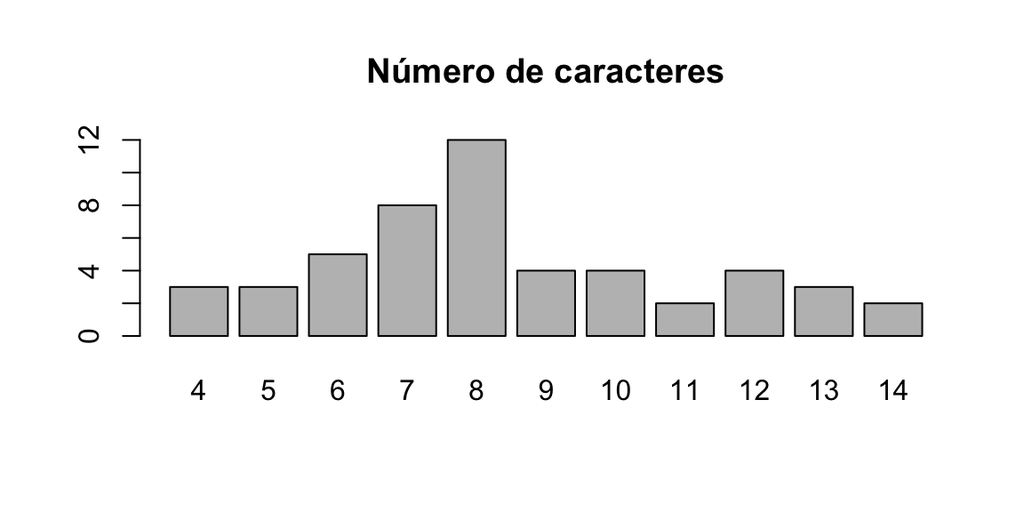

```r
barplot(table(state_chars), main="Número de caracteres")
```

## Ejercicios

Considere el archivo en excel `data_sociodemografica.xlsx` y escriba un código que le permita responder las siguientes preguntas:

- Lea el archivo `data_sociodemografica.xlsx` y cree el objeto `sdata`.
- Considere los dos métodos vistos anteriormente para abreviar las cadenas de la variable `provincia`.
- Realice un conteo de los caracteres de las cadenas de la variable `provincia`.
- Realice un diagrama de frecuencia del número de caracteres.

## Patrones de búsqueda

Ahora vamos a suponer que deseamos seleccionar todos los estados que presentan la letra `w`.

### ¿Cómo lo hacemos?

Usaremos la función `grep` y fijaremos el patrón de búsqueda en `w`.

```r
grep(pattern = "w", states, value = TRUE)
```

```
#> [1] "Delaware"      "Hawaii"        "Iowa"          "New Hampshire"
#> [5] "New Jersey"    "New Mexico"    "New York"
```

Notemos que sólo hemos seleccionado los Estados que contiene la letra w minúscula. Pero ¿qué pasa con aquellos Estados con mayúscula "W"?

```r
grep(pattern = "[wW]", states, value = TRUE)
```

```
#>  [1] "Delaware"      "Hawaii"        "Iowa"          "New Hampshire"
#>  [5] "New Jersey"    "New Mexico"    "New York"      "Washington"
#>  [9] "West Virginia" "Wisconsin"     "Wyoming"
```

## Patrones de búsqueda

Una solución alternativa al problema anterior consiste en convertir los nombres de los Estados en minúscula usando la función `tolower`, para posteriormente realizar la búsqueda de "w".

```r
grep(pattern = "w", tolower(states), value = TRUE)
```

```
#>  [1] "delaware"      "hawaii"        "iowa"          "new hampshire"
#>  [5] "new jersey"    "new mexico"    "new york"      "washington"
#>  [9] "west virginia" "wisconsin"     "wyoming"
```

Alternativamente, podemos convertir los nombres de los Estados en mayúscula usando la función `toupper`, para luego buscar "W".

```r
grep(pattern = "W", toupper(states), value = TRUE)
```

```
#>  [1] "DELAWARE"      "HAWAII"        "IOWA"          "NEW HAMPSHIRE"
#>  [5] "NEW JERSEY"    "NEW MEXICO"    "NEW YORK"      "WASHINGTON"
#>  [9] "WEST VIRGINIA" "WISCONSIN"     "WYOMING"
```

Una última alternativa consiste en adicionar el argumento `ignore.case = TRUE`.